# Assignment 02

### 그래프를 그리기 위해 Python3의 sympy, numpy,matplotlib module을 사용합니다.

### 모듈 정의

```python
from sympy import *
import sympy
import numpy
import matplotlib.pyplot as plt
```

## 1. Define a differentiable function that maps from real number to real number.

- 실수에서 실수로 매핑하는 미분가능함수를 정의합니다.

  $f(x) = \sin{x}$

## 3. Plot the function.

- 그래프로 보입니다.

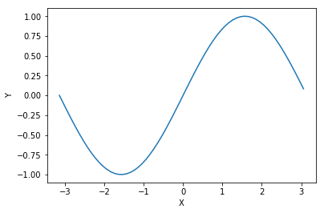

```python
plt.xlabel("X")
plt.ylabel("Y")
x = numpy.arange(-1 * pi , pi , 0.1)
y = [sympy.sin(v) for v in x]
plt.plot(x, y)
plt.show()
```

## 4. Select a point within the domain.

- 도메인안에 점 하나를 고릅니다.
- $x = -\sqrt{2}$ 을 고릅니다

```python
select_point_x = sympy.sqrt(2) * -1
select_point_y = sympy.sin(select_point_x)
```

## 5. Mark the selected point on the function.

- 선택된 점을 함수위에 마킹합니다.

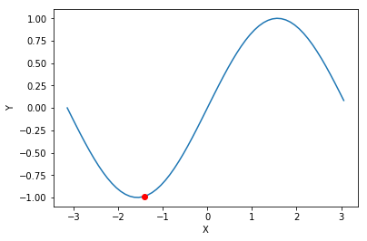

```python
plt.xlabel("X")
plt.ylabel("Y")
x = numpy.arange(-1 * pi , pi , 0.1)
y = [sympy.sin(v) for v in x]
plt.plot(x, y)
plt.plot(select_point_x, select_point_y,'ro')
plt.show()
```

## 6. Define the first-order Taylor approximation at the selected point.

- 선택된 점에 Taylor approximation을 정의합니다.
- first-order Taylor approximation of ${f}$ , near point ${z}$:
  - ${\hat f(x) = f(z)+\frac{\partial f}{\partial x_1}(x_1 - z_1) + \dotsb + \frac{\partial f}{\partial x_n}(x_n - z_n)}$
  - ${\hat f(x)}$ is very close to ${f(x)}$ when ${x_i}$ are all near ${z_i}$
  - ${\hat f(x)}$ is an affine function of ${x}$
- inner product을 사용해 다시 아래 처럼 쓸 수 있다.
  - ${\hat f(x) = f(z) + \nabla f(z)^T(x -z)}$
  - ${\nabla f(z) = \big( \frac{\partial f}{\partial x_1}(z) + \dotsb + \frac{\partial f}{\partial x_n}(z) \big)}$

### sin(x) 에대한 Taylor approximation 함수를 만듭니다.

```python
diff_x,at_point =symbols('x point') #변수 정의
TaylorApproximation = sympy.sin(at_point) + (diff(sympy.sin(at_point), at_point) * (diff_x - at_point))
print(TaylorApproximation)
```

```
(-point + x)*cos(point) + sin(point)
```

### 선택된 점에 대한 Taylor approximation 함수를 [select_point_x - 1, select_point_x + 1]에 대해서 보입니다.

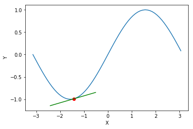

```python
plt.xlabel("X")
plt.ylabel("Y")
x = numpy.arange(-1 * pi , pi , 0.1)
y = [sympy.sin(v) for v in x]

x_ = numpy.arange(select_point_x - 1, select_point_x + 1, 0.1)
y_ = [ TaylorApproximation.subs([(diff_x, v),(at_point,select_point_x)]).evalf() for v in x_]

plt.plot(x, y)
plt.plot(select_point_x, select_point_y,'ro')
plt.plot(x_, y_,'g')
plt.show()
```

## 7. Plot the Taylor approximation with the same domain of the original function.

- 원래 함수의 같은 도메인으로 Taylor approximation를 그래프로 보입니다.

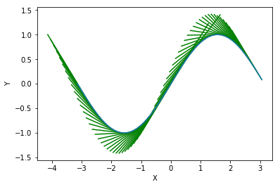

```python
plt.xlabel("X")
plt.ylabel("Y")
x = numpy.arange(-1 * pi , pi , 0.1)
y = [sympy.sin(v) for v in x]

for domain in x:
    x_ = numpy.arange(domain - 1, domain + 1)
    y_ = [ TaylorApproximation.subs([(diff_x, v),(at_point,domain)]).evalf() for v in x_]
    plt.plot(x_, y_,'g')


plt.plot(x, y)
plt.show()
```